# agData Vignette

Derek Wright

October 12, 2018

```r
# devtools::install_github("derekmichaelwright/agData")
library(agData)
library(tidyverse)
```

## Introduction

This is the vignette for the `agData` package.

```r
?agData_FAO_Crops
?agData_FAO_Livestock
?agData_USDA_Crops
?agData_STATCAN_Crops
?agData_STATCAN_Livestock
?agData_STATCAN_Beehives
```

## Load Data

#### A quick exploration of the data

```r
# Load data
xx <- agData_FAO_Crops %>% as.tibble()
xx
```

```
## # A tibble: 2,157,696 x 6
##    Area        Item        Element        Unit    Year     Value
##    <fct>       <fct>       <fct>          <fct>  <dbl>     <dbl>
##  1 Afghanistan Apples      Area harvested ha      1961   2220
##  2 Afghanistan Apples      Yield          hg/ha   1961      6.80
##  3 Afghanistan Apples      Production     tonnes  1961  15100
##  4 Afghanistan Apricots    Area harvested ha      1961   4820
##  5 Afghanistan Apricots    Yield          hg/ha   1961      6.64
##  6 Afghanistan Apricots    Production     tonnes  1961  32000
##  7 Afghanistan Barley      Area harvested ha      1961 350000
##  8 Afghanistan Barley      Yield          hg/ha   1961      1.08
##  9 Afghanistan Barley      Production     tonnes  1961 378000
## 10 Afghanistan Berries nes Area harvested ha      1961   6800
## # ... with 2,157,686 more rows
```

```r
# Spread data to wide format
xx %>%
  unite(Element, Element, Unit) %>%
  spread(Element, Value)
```

```
## # A tibble: 785,117 x 6
##    Area    Item       Year `Area harvested~ Production_tonn~ `Yield_hg/ha`
##    <fct>   <fct>     <dbl>            <dbl>            <dbl>         <dbl>
##  1 Afghan~ Almonds,~  1975                0                0         NA
##  2 Afghan~ Almonds,~  1976             5900             9800          1.66
##  3 Afghan~ Almonds,~  1977             6000             9000          1.5
##  4 Afghan~ Almonds,~  1978             6000            12000          2
##  5 Afghan~ Almonds,~  1979             6000            10500          1.75
##  6 Afghan~ Almonds,~  1980             5800             9900          1.71
##  7 Afghan~ Almonds,~  1981             5800             8000          1.38
##  8 Afghan~ Almonds,~  1982             5800            11000          1.90
##  9 Afghan~ Almonds,~  1983             5700             9700          1.70
## 10 Afghan~ Almonds,~  1984             5700            10500          1.84
## # ... with 785,107 more rows
```

```r
# List measurements
xx %>% distinct(Element)
```

```
## # A tibble: 3 x 1
##   Element
##   <fct>
## 1 Area harvested
## 2 Yield
## 3 Production
```

```r
# List areas
xx %>% distinct(Area)
```

```
## # A tibble: 258 x 1
##    Area
##    <fct>
##  1 Afghanistan
##  2 Albania
##  3 Algeria
##  4 American Samoa
##  5 Angola
##  6 Antigua and Barbuda
##  7 Argentina
##  8 Australia
##  9 Austria
## 10 Bahamas
## # ... with 248 more rows
```

```r
# List crops
xx %>% distinct(Item)
```

```
## # A tibble: 180 x 1
##    Item
##    <fct>
##  1 Apples
##  2 Apricots
##  3 Barley
##  4 Berries nes
##  5 Cotton lint
##  6 Cottonseed
##  7 Figs
##  8 Fruit, citrus nes
##  9 Fruit, fresh nes
## 10 Fruit, stone nes
## # ... with 170 more rows
```

## Example 1: Rapeseed production

#### Improvments in oil quality, acheived through plant breeding has resulted in Rapeseed/Canola becoming one of the worlds major oil crops.

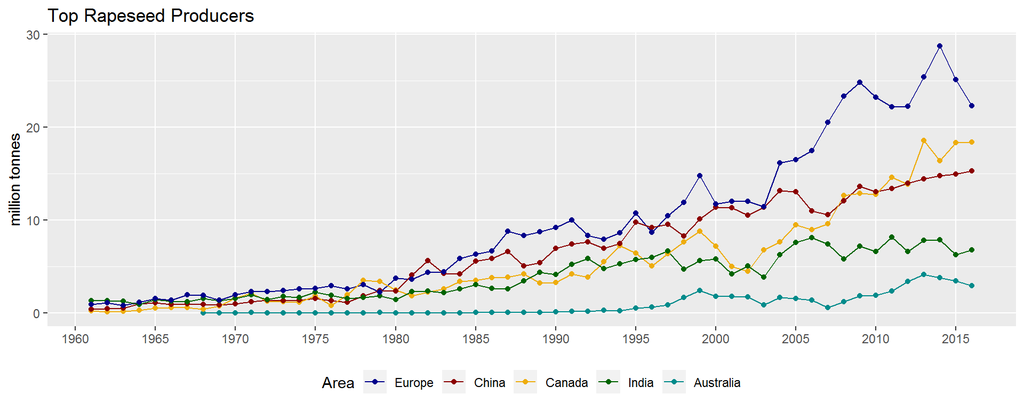

```r
# Prep data
areas <- c("Europe", "China", "Canada", "India", "Australia")
cols  <- c("darkblue", "darkred", "darkgoldenrod2", "darkgreen", "darkcyan")
xx <- agData_FAO_Crops %>%
  filter(Item == "Rapeseed",
         Area %in% areas,
         Element == "Production") %>%
  mutate(Area = factor(Area, levels = areas))
# Plot
ggplot(xx, aes(x = Year, y = Value / 1000000, color = Area)) +
  geom_line() +
  geom_point() +
  scale_color_manual(values = cols) +
  scale_x_continuous(breaks       = seq(1960, 2015, by = 5),
                     minor_breaks = seq(1960, 2015, by = 5)) +
  theme(legend.position = "bottom") +
  labs(title = "Top Rapeseed Producers",
       y = "million tonnes", x = NULL)
```

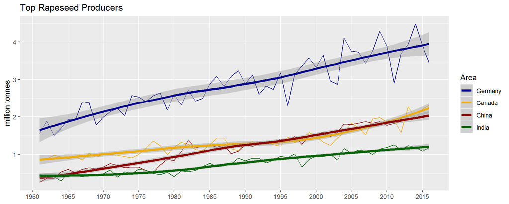

```r
# Prep data
areas <- c("Germany", "Canada", "China", "India")
cols  <- c("darkblue", "darkgoldenrod2", "darkred", "darkgreen")
xx <- agData_FAO_Crops %>%
  filter(Item == "Rapeseed",
         Area %in% areas,
         Element == "Yield") %>%
  mutate(Area = factor(Area, levels = areas))
# Plot
ggplot(xx, aes(x = Year, y = Value, color = Area)) +
  geom_line() +
  geom_smooth(method = "loess", size = 1.5) +
  scale_color_manual(values = cols) +
  scale_x_continuous(breaks       = seq(1960, 2015, by = 5),
                     minor_breaks = seq(1960, 2015, by = 5)) +
  labs(title = "Top Rapeseed Producers",
       y = "million tonnes", x = NULL)
```

## Example 2: Wheat production in India and Mexico

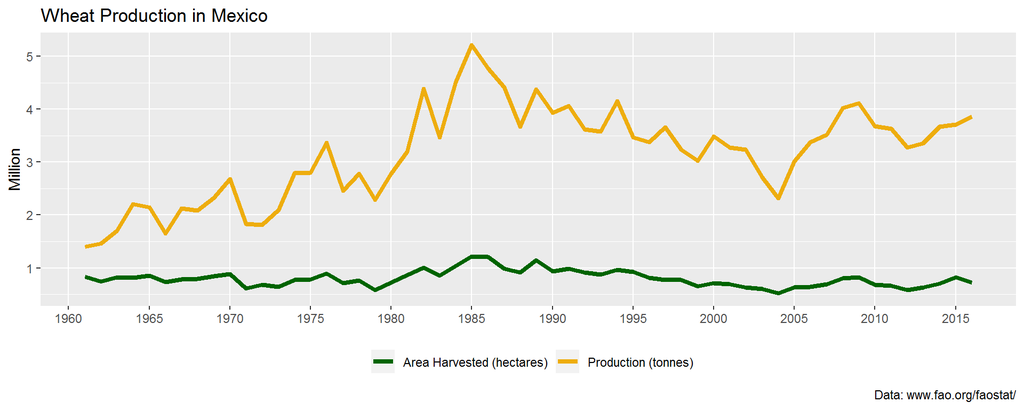

```r
# Prep data
xx <- agData_FAO_Crops %>%
  filter(Item == "Wheat",
         Area == "Mexico")
# Plot
ggplot(xx %>% filter(Element != "Yield"), aes(x = Year, y = Value / 1000000, color = Element)) +
  geom_line(size = 1.5) +
  theme(legend.position = "bottom") +
  scale_color_manual(name   = NULL,
                     labels = c("Area Harvested (hectares)", "Production (tonnes)"),
                     values = c("Dark Green", "darkgoldenrod2")) +
  scale_x_continuous(breaks       = seq(1960, 2015, by = 5),
                     minor_breaks = seq(1960, 2015, by = 5)) +

  labs(title   = "Wheat Production in Mexico",
       caption = "Data: www.fao.org/faostat/",
       y       = "Million",
       x       = NULL)
```

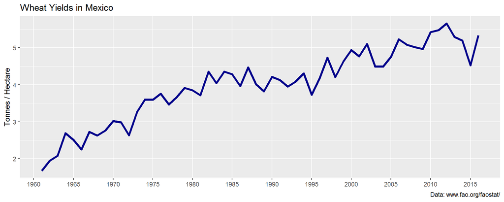

```r
# Plot
ggplot(xx %>% filter(Element =="Yield"), aes(x = Year, y = Value) ) +
  geom_line(size = 1.5, color = "Dark Blue") +
  scale_x_continuous(breaks       = seq(1960, 2015, by = 5),
                     minor_breaks = seq(1960, 2015, by = 5)) +
  labs(title   = "Wheat Yields in Mexico",
       caption = "Data: www.fao.org/faostat/",
       y       = "Tonnes / Hectare",
       x       = NULL)
```

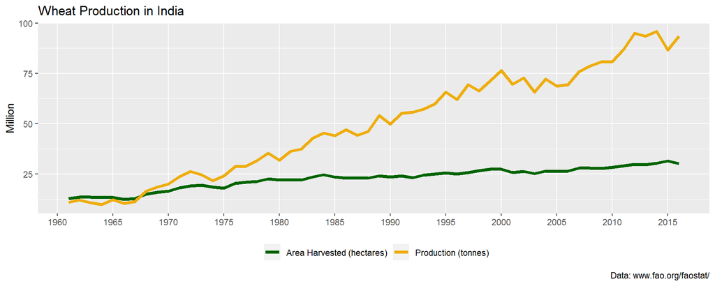

```r
# Prep data
xx <- agData_FAO_Crops %>%
  filter(Item == "Wheat",
         Area == "India")
# Plot
ggplot(xx %>% filter(Element != "Yield"), aes(x = Year, y = Value / 1000000, color = Element)) +
  geom_line(size = 1.5) +
  theme(legend.position = "bottom") +
  scale_color_manual(name   = NULL,
                     labels = c("Area Harvested (hectares)", "Production (tonnes)"),
                     values = c("Dark Green", "darkgoldenrod2")) +
  scale_x_continuous(breaks       = seq(1960, 2015, by = 5),
                     minor_breaks = seq(1960, 2015, by = 5)) +

  labs(title   = "Wheat Production in India",
       caption = "Data: www.fao.org/faostat/",
       y       = "Million",
       x       = NULL)
```

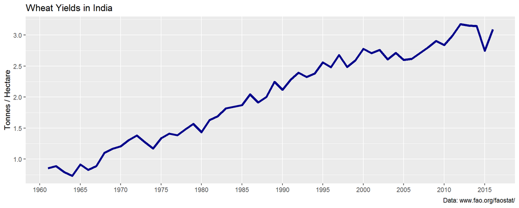

```r
# Plot
ggplot(xx %>% filter(Element =="Yield"), aes(x = Year, y = Value) ) +
  geom_line(size = 1.5, color = "Dark Blue") +
  scale_x_continuous(breaks       = seq(1960, 2015, by = 5),
                     minor_breaks = seq(1960, 2015, by = 5)) +
  labs(title   = "Wheat Yields in India",
       caption = "Data: www.fao.org/faostat/",
       y       = "Tonnes / Hectare",
       x       = NULL)
```

## Example 3: Wheat and Maize Yields in Germany vs Europe

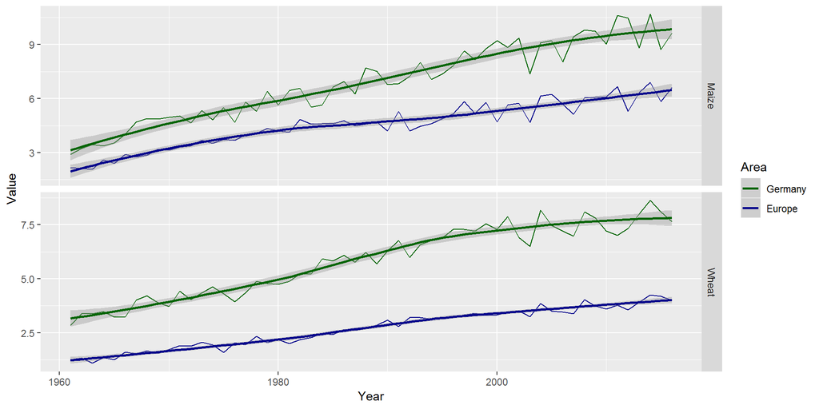

```r
# Prep data
xx <- agData_FAO_Crops %>%
  filter(Area %in% c("Germany", "Europe"),
         Item %in% c("Maize", "Wheat"),
         Element == "Yield") %>%
  mutate(Area = factor(Area, levels = c("Germany", "Europe")))
# Plot
ggplot(xx, aes(x = Year, y = Value, color = Area)) +
  geom_line() +
  geom_smooth(method = "loess") +
    facet_grid(Item~., scales = "free_y") +
  scale_color_manual(values = c("darkgreen", "darkblue"))
```

## Example 4: FOA lentil data for Canada

#### Since the introduction of lentil as a crop for the Canadian Prairies (1973), Saskatchewan has become the worlds largest producer of lentils. The first variety, “Laird”, was registered in 1979.

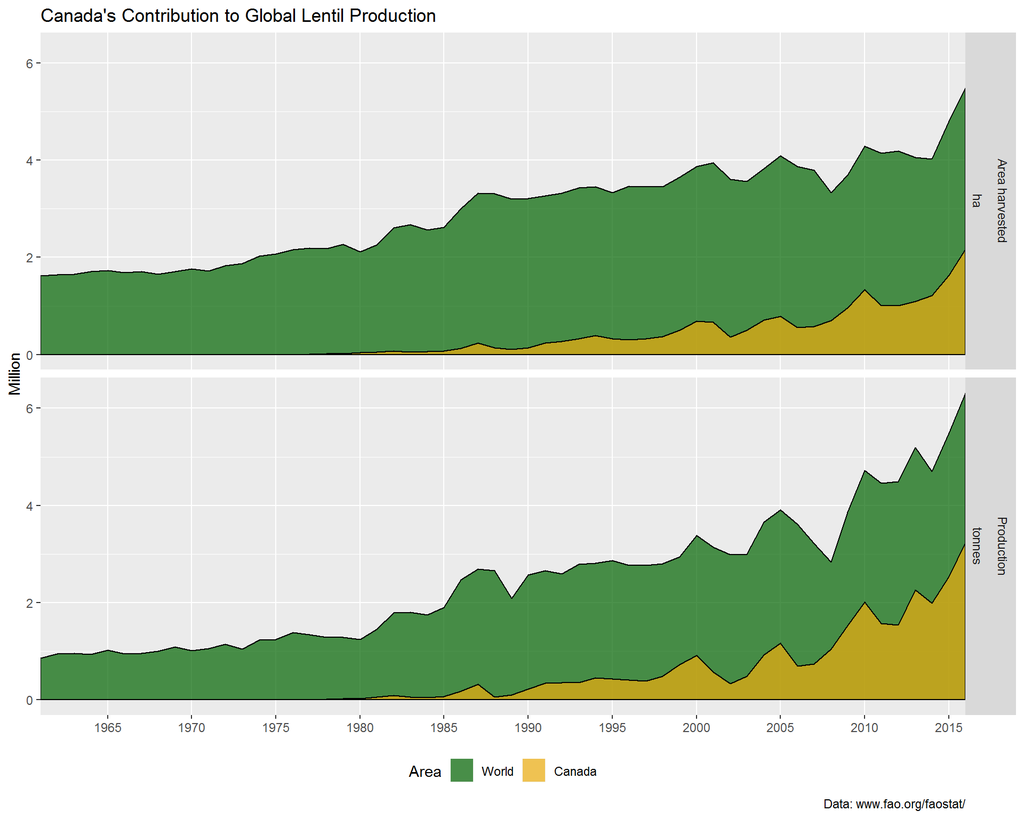

```r
# Prep data
xx <- agData_FAO_Crops %>%
  filter(Item    == "Lentils",
         Element != "Yield",
         Area %in% c("Canada", "World") ) %>%
  mutate(Area = factor(Area, levels = c("World", "Canada")))
# Plot
ggplot(xx, aes(x = Year, y = Value / 1000000, fill = Area, color = I("Black"))) +
  geom_area(position = "identity", alpha = 0.7) +
  facet_grid(Element+Unit~.) +
  theme(legend.position = "bottom") +
  scale_fill_manual(values = alpha(c("Dark Green", "darkgoldenrod2"), 0.6)) +
  scale_x_continuous(breaks       = seq(1960, 2015, by = 5),
                     minor_breaks = seq(1960, 2015, by = 5),
                     expand = c(0,0))  +
  labs(title   = "Canada's Contribution to Global Lentil Production",
       caption = "Data: www.fao.org/faostat/",
       y = "Million", x = NULL)
```

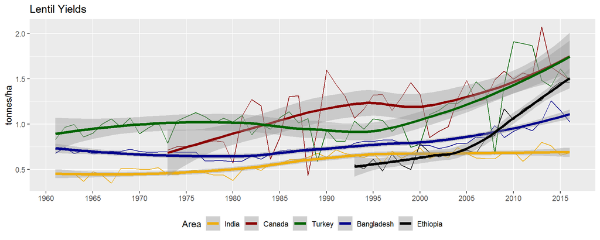

```r
# Prep data
areas <- c("India", "Canada", "Turkey", "Bangladesh", "Syria", "Ethiopia")
cols  <- c("darkgoldenrod2", "darkred", "darkgreen", "darkblue", "black", "darkcyan")
xx <- agData_FAO_Crops %>%
  filter(Item == "Lentils",
         Area %in% areas,
         Element == "Yield") %>%
  mutate(Area = factor(Area, levels = areas))
# Plot
ggplot(xx, aes(x = Year, y = Value, color = Area)) +
  geom_line() +
  geom_smooth(method = "loess", size = 1.5) +
  scale_x_continuous(breaks       = seq(1960, 2015, by = 5),
                     minor_breaks = seq(1960, 2015, by = 5)) +
  scale_color_manual(values = cols) +
  theme(legend.position = "bottom") +
  labs(title = "Lentil Yields",
       y = "tonnes/ha", x = NULL)
```

## Example 5: USDA maize

#### The development of hybrid seed production in maize has led to major increases in crop yield in the United States.

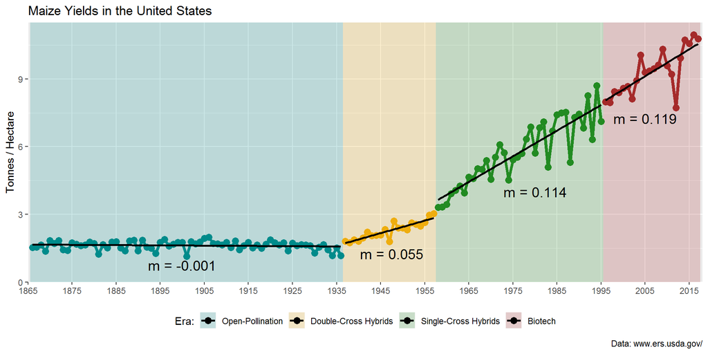

```r
# Prep data
xx <- agData_USDA_Crops %>%
  filter(Item == "Maize", Element == "Yield") %>%
  mutate(Era = ifelse(Year < 1937, "Open-Pollination",
                ifelse(Year < 1958, "Double-Cross Hybrids",
                 ifelse(Year < 1996, "Single-Cross Hybrids", "Biotech"))),
         Era = factor(Era, levels = c("Open-Pollination", "Double-Cross Hybrids",
                                      "Single-Cross Hybrids", "Biotech")))
# Prep rect data
x2 <- xx %>%
  group_by(Era) %>%
  summarise(min = min(Year), max = max(Year))
# Calculate slopes
c1 <- round(summary(lm(data = xx %>% filter(Era=="Open-Pollination"), Value~Year))$coefficients[2], 3)
c2 <- round(summary(lm(data = xx %>% filter(Era=="Double-Cross Hybrids"), Value~Year))$coefficients[2], 3)
c3 <- round(summary(lm(data = xx %>% filter(Era=="Single-Cross Hybrids"), Value~Year))$coefficients[2], 3)
c4 <- round(summary(lm(data = xx %>% filter(Era=="Biotech"), Value~Year))$coefficients[2], 3)
# Create color palette
cols <- c("darkcyan", "darkgoldenrod2", "Forest Green", "Brown")
# Plot
ggplot(xx, aes(fill = Era)) +
  geom_rect(data = x2, aes(xmin = min-0.5, xmax = max+0.5, ymin = -Inf, ymax = Inf), alpha = 0.2) +
  geom_line(size = 1.5, aes(x = Year, y = Value, color = Era)) +
  geom_point(size = 3, aes(x = Year, y = Value, color = Era)) +
  geom_smooth(method = "lm", se = F, colour = "Black", aes(x = Year, y = Value)) +
  scale_color_manual(name = "Era:", values = cols, guide = F) +
  scale_fill_manual(name = "Era:", values = cols) +
  scale_x_continuous(breaks       = seq(1865, 2015, by = 10),
                     minor_breaks = seq(1865, 2015, by = 10)) +
  coord_cartesian(xlim = c(1865, 2018), ylim = c(0, 11.5), expand = c(0, 0)) +
  annotate("text", x = 1900, y = 0.75, size = 5, label = paste("m =", c1)) +
  annotate("text", x = 1947.5, y = 1.25, size = 5, label = paste("m =", c2)) +
  annotate("text", x = 1980, y = 4, size = 5, label = paste("m =", c3)) +
  annotate("text", x = 2005, y = 7.25, size = 5, label = paste("m =", c4)) +
  theme(legend.position = "bottom") +
  labs(title   = "Maize Yields in the United States",
       caption = "Data: www.ers.usda.gov/",
       y       = "Tonnes / Hectare",
       x       = NULL)
```

## Example 6: Maize yields in the developed vs developing world

#### Maize yields in developing countries have lagged behind those in developed countries. This is due to a conbination of factors, including lack of access to crop inputs, machinery, and improved crop varieties.

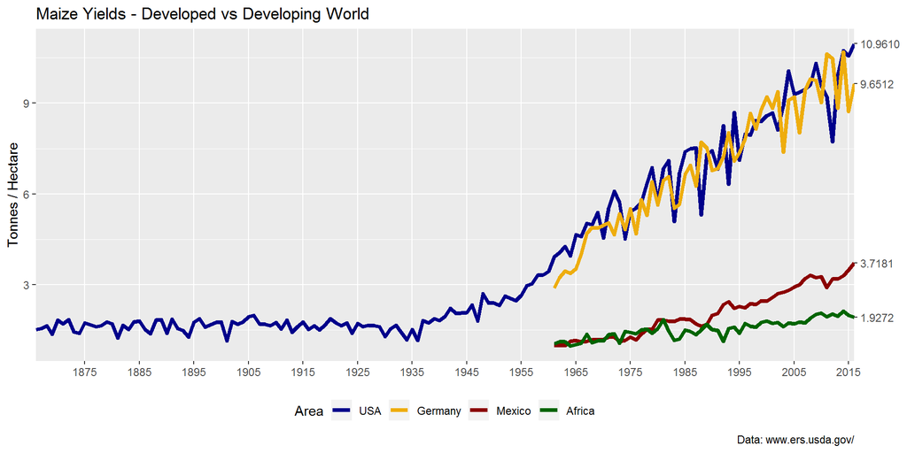

```r
# Prep data
x1 <- agData_USDA_Crops %>%
  filter(Item    == "Maize",
         Element == "Yield",
         Year != 2017)
x2 <- agData_FAO_Crops %>%
  filter(Item    == "Maize",
         Element == "Yield",
         Area %in% c("Germany", "Mexico", "Africa"))
xx <- bind_rows(x1, x2) %>%
  mutate(Area = factor(Area, levels = c("USA", "Germany", "Mexico", "Africa")))
xE <- xx %>% top_n(1, Year) %>% pull(Value)
# Plot
ggplot(xx, aes(x = Year, y = Value, color = Area)) +
  geom_line(size = 1.5) +
  theme(legend.position = "bottom") +
  scale_color_manual(values = c("Dark Blue", "darkgoldenrod2", "Dark Red", "Dark Green")) +
  scale_x_continuous(breaks       = seq(1865, 2015, by = 10),
                     minor_breaks = seq(1865, 2015, by = 10),
                     expand = c(0, 0)) +
  scale_y_continuous(sec.axis = sec_axis(~ ., breaks = xE)) +
  labs(title   = "Maize Yields - Developed vs Developing World",
       caption = "Data: www.ers.usda.gov/",
       y       = "Tonnes / Hectare",
       x       = NULL)
```

## Example 7: USDA Maize vs Wheat yields

#### Maize yeilds have increased on a much faster pace than wheat, in part due to the adoption of hybrid seed in Maize.

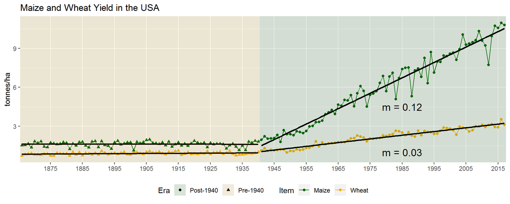

```r
# Prep data
xx <- agData_USDA_Crops %>%
  filter(Item %in% c("Maize", "Wheat"),
         Element == "Yield") %>%
  mutate(Era = ifelse(Year <= 1940, "Pre-1940", "Post-1940"))
#
x2 <- xx %>%
  group_by(Era) %>%
  summarise(min = min(Year), max = max(Year))
#
c1 <- round(summary(lm(data = xx %>% filter(Item=="Maize",Era=="Post-1940"), Value~Year))$coefficients[2], 2)
c2 <- round(summary(lm(data = xx %>% filter(Item=="Wheat",Era=="Post-1940"), Value~Year))$coefficients[2], 2)
# Plot
ggplot(xx) +
  geom_line(aes(x = Year, y = Value, color = Item)) +
  geom_point(aes(x = Year, y = Value, color = Item, shape = Era)) +
  geom_smooth(data = xx %>% filter(Item == "Wheat"),
              method = "lm", se = F, colour = "Black", aes(x = Year, y = Value, group = Era)) +
  geom_smooth(data = xx %>% filter(Item == "Maize"),
              method = "lm", se = F, colour = "Black", aes(x = Year, y = Value, group = Era)) +
  geom_rect(data = x2, aes(xmin = min-0.5, xmax = max+0.5, ymin = -Inf, ymax = Inf, fill = Era), alpha = 0.1) +
  annotate("text", x = 1985, y = 4.5, size = 5, label = paste("m =", c1)) +
  annotate("text", x = 1985, y = 1, size = 5, label = paste("m =", c2)) +
  scale_x_continuous(breaks       = seq(1865, 2015, by = 10),
                     minor_breaks = seq(1865, 2015, by = 10),
                     expand = c(0,0)) +
  scale_color_manual(values = c("darkgreen", "darkgoldenrod2")) +
  scale_fill_manual(values = c("darkgreen", "darkgoldenrod2")) +
  theme(legend.position = "bottom") +
  labs(title = "Maize and Wheat Yield in the USA",
       y = "tonnes/ha", x = NULL)
```

## Example 8: FAO and STATCAN honeybee data

#### Neonicotinoids are often blamed for honeybee declines, but the data suggests a more complicated story.

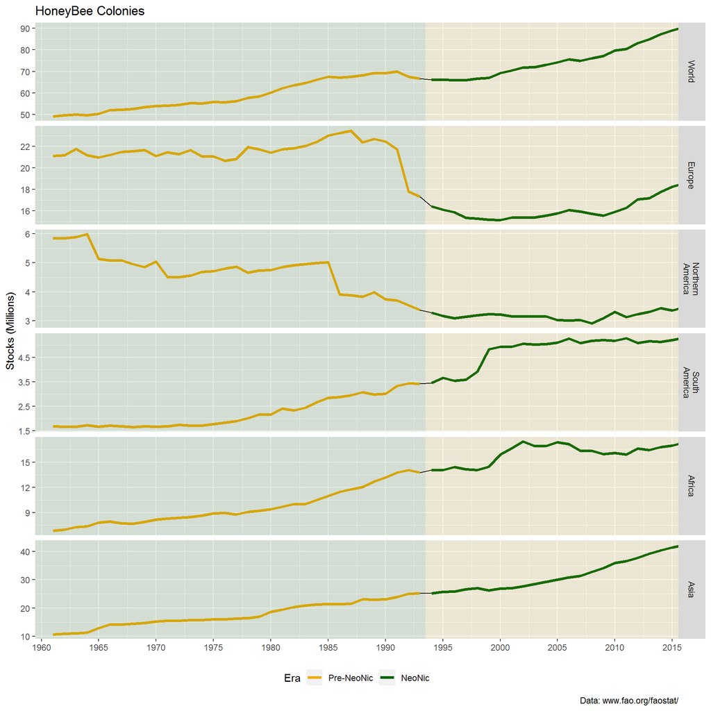

```r
# Prep data
areas <- c("World", "Europe", "Northern America", "South America", "Africa", "Asia")
xx <- agData_FAO_Livestock %>%
  filter(Item == "Beehives") %>%
  mutate(Era = ifelse(Year >= 1994, "NeoNic", "Pre-NeoNic"),
         Era = factor(Era, levels = c("Pre-NeoNic", "NeoNic") ) ) %>%
  filter(Area %in% areas) %>%
  mutate(Area = factor(Area, levels = areas))
# Plot
ggplot(data = xx, aes(x = Year, y = Value / 1000000)) +
  geom_line() + geom_line(aes(color = Era), size = 1.25) +
  facet_grid(Area ~ ., scales = "free_y", labeller = label_wrap_gen(width = 10)) +
  theme(legend.position = "bottom") +
  scale_color_manual(values = c("darkgoldenrod2", "Dark Green")) +
  scale_x_continuous(breaks = seq(1960, 2015, by = 5)) +
  coord_cartesian(xlim = c(1962, 2013)) +
  annotate("rect", xmin = 1940, xmax = 1993.5, ymin = -Inf, ymax = Inf, fill = "Dark Green",     alpha = 0.1) +
  annotate("rect", xmin = 1993.5, xmax = 2035, ymin = -Inf, ymax = Inf, fill = "darkgoldenrod2", alpha = 0.1) +
  labs(title = "HoneyBee Colonies",
       caption = "Data: www.fao.org/faostat/",
       y = "Stocks (Millions)",
       x = NULL)
```

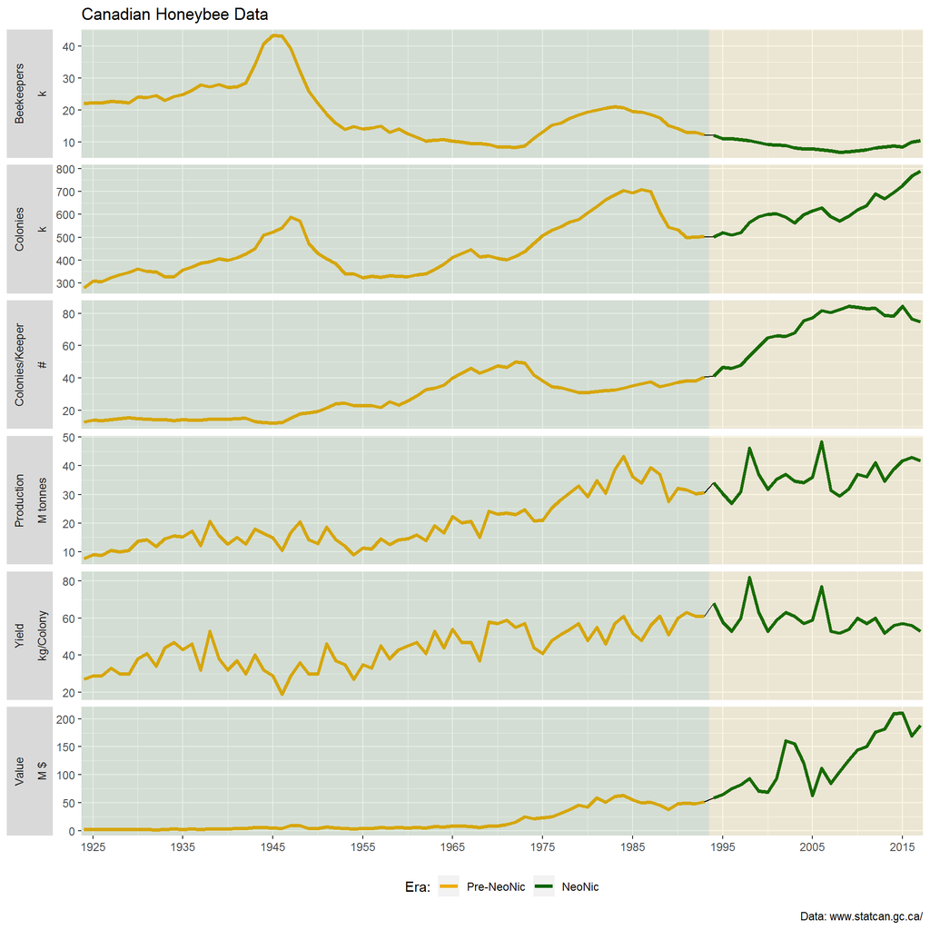

```r
# Prep data
levs <- c("Beekeepers", "Colonies", "Colonies/Keeper",  "Production", "Yield", "Value")
xx <- agData_STATCAN_Beehives %>%
  filter(Area == "Canada") %>%
  select(-Unit) %>%
  spread(Element, Value) %>%
  mutate(Colonies = Colonies / 1000,
         Production = Production / 1000000,
         Beekeepers = Beekeepers / 1000) %>%
  gather("Element", "Value", Colonies, Production, Beekeepers, ColoniesPerBeekeeper, Yield, Value) %>%
  mutate(Element = plyr::mapvalues(Element, "ColoniesPerBeekeeper", "Colonies/Keeper"),
         Element = factor(Element, levels = levs),
         Unit = plyr::mapvalues(Element, levs, c("k","k","#","M tonnes","kg/Colony","M $")),
         Era = ifelse(Year >= 1994, "NeoNic", "Pre-NeoNic"),
         Era = factor(Era, levels = c("Pre-NeoNic", "NeoNic")))
#
ggplot(xx, aes(x = Year, y = Value)) +
  geom_line() +
  geom_line(aes(color = Era), size = 1.25) +
  facet_grid(Element + Unit ~ ., scales = "free", switch = "y") +
  scale_colour_manual(name = "Era:", values = c("darkgoldenrod2", "Dark Green")) +
  scale_x_continuous(breaks = seq(1925, 2015, by = 10)) +
  coord_cartesian(xlim = c(min(xx$Year)+4, max(xx$Year)-4)) +
  annotate("rect", xmin = 1905, xmax = 1993.5, ymin = -Inf, ymax = Inf, fill = "Dark Green",     alpha = 0.1) +
  annotate("rect", xmin = 1993.5, xmax = 2035, ymin = -Inf, ymax = Inf, fill = "darkgoldenrod2", alpha = 0.1) +
  theme(strip.placement = "outside", legend.position = "bottom", axis.title.y = element_text(hjust = 0)) +
  labs(title = "Canadian Honeybee Data",
       caption = "Data: www.statcan.gc.ca/",
       y = NULL, x = NULL)
```

## Example 9: gganimate example

[figure not shown]

```r
library(gganimate)
# Prep data
xx <- agData_STATCAN_Beehives %>%
  filter(Area    == "Canada",
         Element == "Colonies")
# Create GIF
mp <- ggplot(xx, aes(Year, Value / 1000, group = Area)) +
  geom_line() +
  labs(title = "Honeybee Colonies in Canada - {frame_along}",
       caption = "Data: www.statcan.gc.ca/",
       y = "Thousand Colonies") +
  transition_reveal(Area, Year)
animate(mp, fps = 5)
```

```r
anim_save("anim.gif")
```

## HexSticker Creation

```r
library(hexSticker)
# Prep data
xx <- agData_FAO_Crops %>%
  filter(Area    == "Canada",
         Item    == "Lentils",
         Element == "Production")
# Create sticker
mp <- ggplot(xx, aes(x = Year, y = Value/1000000)) +
  geom_line() + theme(axis.text = element_blank(), axis.ticks = element_blank()) +
  labs(x = NULL, y = NULL) +
  theme_transparent()
sticker(mp,
        package="agData", p_color = "Black", p_size = 30,
        s_x = 1, s_y = 0.8, s_width = 1.75, s_height = 0.8,
        h_fill = "#614105", h_color = "darkolivegreen", h_size = 3)
```